# Practical Machine Learning - Project

mat

11/21/2015

## Overview

This project analyzes the data collected by the [Human Activity Recognition](http://groupware.les.inf.puc-rio.br/har) research from Groupware @ LES. The goal is to go beyond identify *what activity* the human subject is doing but *how well* is the activity performed. The subjects were wearing multiple body sensors (Fitbit-like) and executing a series of correct weight lifting exercices (Class A) and typical mistakes (Class B to E).

After preparation of the raw data and separation into training set and testing set, 3 models are assessed. The best performing model is the Random Forest algorithm. **The final accuracy on the test set is $99.2\%$**.

Once the model is trained and tested, it is used to predict the 20 cases from the assignment. **The success rate of prediction is $100\%$**.

## Data Preparation & Exploration

```r
data <- read.csv('pml-training.csv', header = TRUE)
inTrain  <- createDataPartition(data$classe, p=0.6, list=FALSE)
# Training set: 11776 rows x 160 columns
# Testing set:  7846 rows  x 160 columns
training <- data[inTrain,]
testing  <- data[-inTrain,]
# Remove columns that are not predictors: X, user_name, raw_timestamp_part_1,
# raw_timestamp_part_2, cvtd_timestamp, new_window, num_window
# 152 predictors remaining
training <- training[, -c(1:7)]
testing  <- testing[, -c(1:7)]
# Remove 54 variables with near zero variance : 99 predictors remaining
nzv_id <- nearZeroVar(training)
training <- training[, -nzv_id]
testing  <- testing[, -nzv_id]
# Remove 46 variables with more than 90% of NA values
# 52 predictors eventually remaining
nb_lin <- dim(training)[[1]]
nb_col <- dim(training)[[2]]
na_id <- sapply(1:nb_col, function(x) {
    na_ratio <- sum(is.na(training[, x])) / nb_lin })
is_na <- which(na_id > .9)
training <- training[, -is_na]
testing  <- testing[, -is_na]
```

The data have been randomly split into a training set ($60\%$) and a testing set ($40\%$). The cross-validation splits are performed during the run of the models.

The initial number of features is $159$, which is quite high. We are reducing the number of features in order to run less computationally-intensive models:

- The first $7$ columns are removed because they are not predictors per se: ID, username, timestamps, etc..
- $54$ columns with near zero variance are removed as they are useless for training the model
- $46$ columns with more than 90% of NA values are removed as they won’t bute enough to the training

$52$ predictors are eventually remaining, which is much better. In order to boost the performance of the modelling, this R program is run on an 4-core AWS instance. The `doMC` package enables the parallelization of the computations.

## Model Selection

### Recursive Partitioning Tree

```r
model_rpart <- train(classe ~ ., data = training, method = 'rpart')
```

The first assessed model is Recursive Partitioning Tree. It is fast to run.

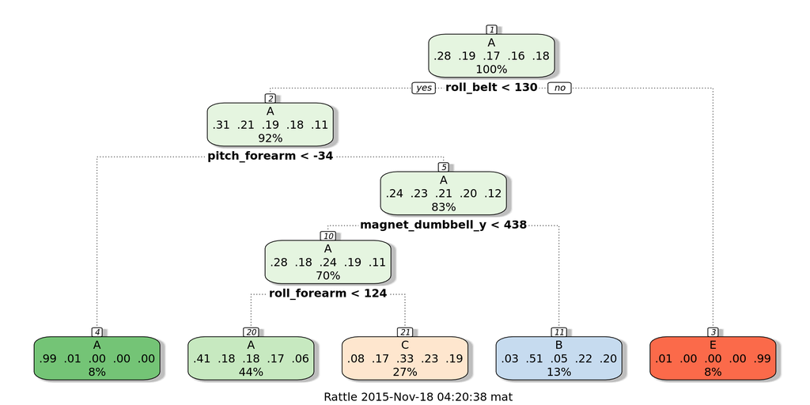

```r
pred_rpart_train <- predict(model_rpart, training)
cm_rpart_train   <- confusionMatrix(pred_rpart_train, training$classe)
pred_rpart_test  <- predict(model_rpart, testing)
cm_rpart_test    <- confusionMatrix(pred_rpart_test, testing$classe)
# No D in the model?
fancyRpartPlot(model_rpart$finalModel)
```

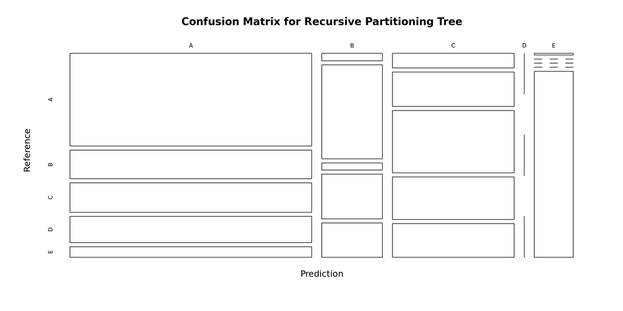

```r
plot(cm_rpart_test$table, col = cm_rpart_test$byClass,
     main = "Confusion Matrix for Recursive Partitioning Tree")
```

The Training Overall Accuracy is $0.497$ and the Testing Overall Accuracy is $0.494$ . This is not satisfactory. In addition, the D class is present in no leaf of the tree: It means this class cannot be predicted by the Model!

### Gradient Boosting

```r
model_gbm <- train(classe ~ ., data = training, method = 'gbm')
```

The second assessed model is Gradient Boosting. It takes a few minutes to run on a 4-core AWS instance.

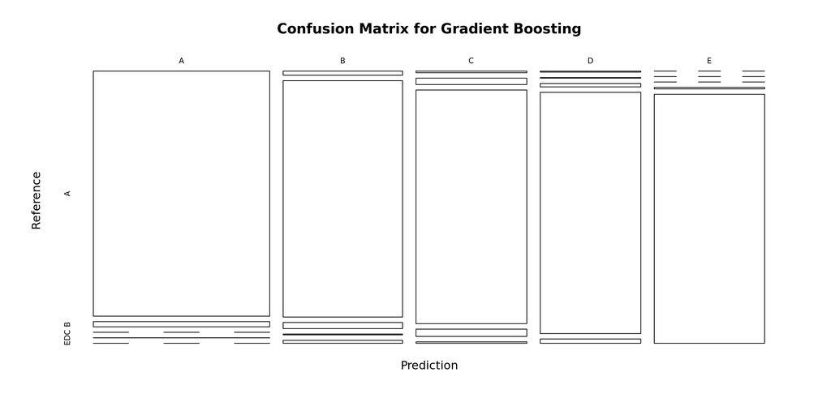

The Training Overall Accuracy is $0.974$ and the Testing Overall Accuracy is $0.964$. This is a satisfactory level, but let’s see if we can find a more accurate model.

### Random Forest

```r
model_rf <- train(classe ~ ., data = training, method = 'rf',
    trcontrol = trainControl(method = 'cv', number = 3))
```

The third assessed model is Random Forest. It takes around 30 minutes to run on a 4-core AWS instance.

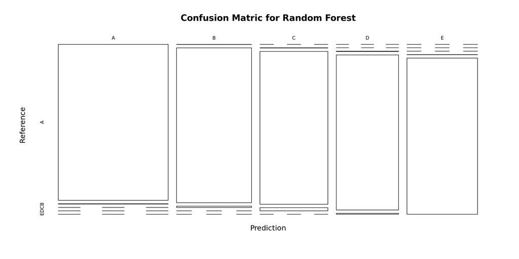

```r
pred_rf_train <- predict(model_rf, training)
cm_rf_train   <- confusionMatrix(pred_rf_train, training$classe)
pred_rf_test  <- predict(model_rf, testing)
cm_rf_test    <- confusionMatrix(pred_rf_test, testing$class)
plot(cm_rf_test$table, col = cm_rf_test$byClass,
     main = "Confusion Matric for Random Forest")
```

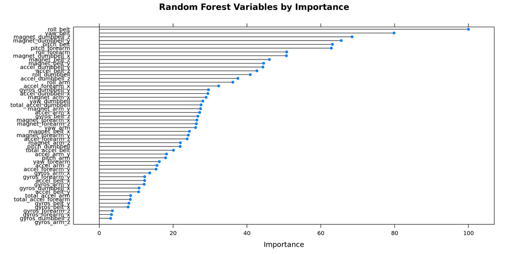

```r
plot(varImp(model_rf), main = "Random Forest Variables by Importance")
```

The Training Overall Accuracy is $1$ and the Testing Overall Accuracy is $0.992$. This is satisfactory. The Random Forest Model will be used for the prediction of the Test Set.

## Prediction For The 20 Test Cases

```r
data_test <- read.csv('pml-testing.csv', header = TRUE)
predict(model_rf, data_test)
```

```
##  [1] B A B A A E D B A A B C B A E E A B B B
## Levels: A B C D E
```

The prediction results are submitted manually by uploading the result files. $100\%$ of the predictions are correct.